# Assignment 1: Boot a Bird

Jory Griffith

1/5/2021

## The first part of this document is class notes, please skip to “My Work” Section

```r
library(tidyverse)
library(boot)
setwd("/Users/jorygriffith/Desktop/Machine Learning/Mod1.Bootstrapping")
birds<-read.csv("KillarneyBirds.csv")
```

Simpson’s diversity takes into account the number of individuals (n) in each species (i) and the total number of individuals of all species (N). I will calculate the Simpson’s diversity index in each habitat and compare them.

First I will look at the number of individuals in each species in the oak1 habitat

```r
n<-birds$Oak1
n
```

```
##  [1] 35 26 25 21 16 11  6  5  3  3  3  3  3  2  2  2  1  1  1  1  0  0  0  0  0
## [26]  0  0  0  0  0  0
```

And the total of n as N (in just the Oak1 habitat)

```r
N<-sum(n)
N
```

```
## [1] 170
```

From that we can calculate the Simpson’s index (D) of the Oak1 habitat

```r
D<-1-sum(n*(n-1))/(N*(N-1))
D
```

```
## [1] 0.8852767
```

We can write a function to do this for any vector of species.

```r
sdiFunc<-function(x){
  N<-sum(x)
  D<-1-sum(x*(x-1)) / (N*(N-1))
  D
}

oak1Div<-sdiFunc(x=birds$Oak1)
oak1Div
```

```
## [1] 0.8852767
```

Then we can apply that function to all the columns (habitats) in birds

```r
sdiHabitat<-apply(birds[,-1], MARGIN=2, FUN=sdiFunc) # don't want first column because it is the bird species names
sdiHabitat
```

```
##      Oak1      Oak2      Oak3       Yew     Sitka    Norway     Mixed    Patchy
## 0.8852767 0.8738996 0.8347812 0.8910759 0.7780180 0.8284879 0.8996337 0.9179604
##    Swampy
## 0.9044444
```

Visualization of bird diversity by habitat

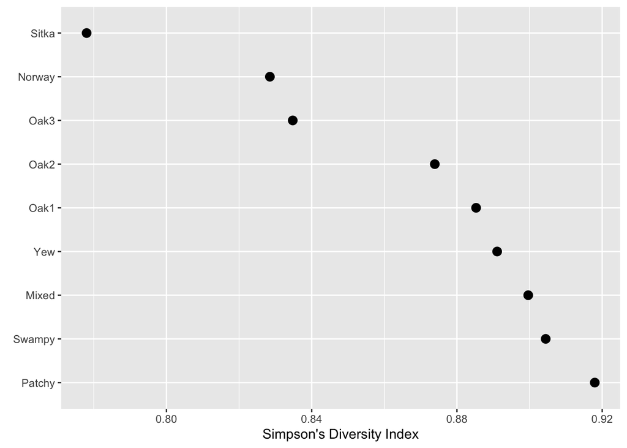

```r
sdiHabitat <- sdiHabitat %>% as_tibble %>% add_column(Habitat = names(sdiHabitat))
ggplot(data = sdiHabitat, mapping = aes(x=value,y=reorder(Habitat,-value))) +
  geom_point(size=3) +
  labs(x="Simpson's Diversity Index",y=element_blank())
```

We do not know if this is meaningful because we don’t have any error for this. We can get this through bootstrapping!

# Bootstrapping

We will take 10,000 samples of the diversity data of Oak1 habitat, with replacement. Taking sample that is the same length as the initial sample. R= number of bootstrap replicates.

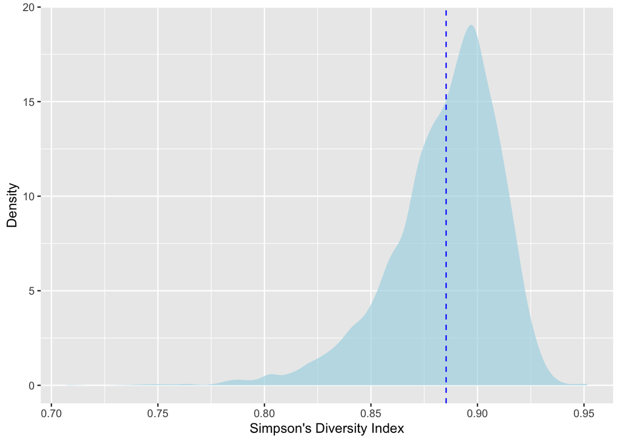

```r
R<-1e4 #10,000 replicates
# structure to hold results
sdiDistOak1<-numeric()
for(i in 1:R){
  x<-birds$Oak1
  xSamp<-sample(x,size=length(x), replace=TRUE)
  sdiDistOak1[i]<-sdiFunc(xSamp) #sdiDistOak1 will be a vector of 10,000 diversity estimates for Oak1
}

ggplot() + geom_density(mapping=aes(x=sdiDistOak1),
                        fill="lightblue",color=NA,alpha=0.7) +
  geom_vline(xintercept = oak1Div,color="blue",linetype="dashed") +
  labs(x="Simpson's Diversity Index",y="Density")
```

Mean of the distribution is where our line is but we have much more information now.

```r
mean(sdiDistOak1)
```

```
## [1] 0.8849621
```

Can calculate a confidence interval for the statistic using the quantile function.

```r
ci95Oak1 <- quantile(sdiDistOak1,probs = c(0.025,0.975))
names(ci95Oak1) <- c("lower","upper")
ci95Oak1
```

```
##     lower     upper
## 0.8221762 0.9229668
```

Plot with confidence interval added.

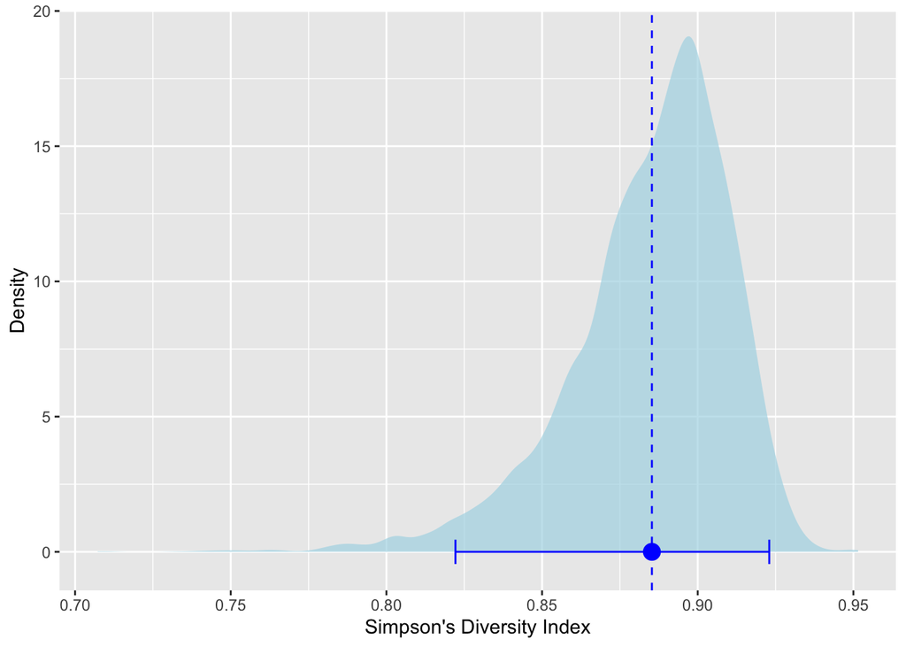

```r
ggplot() + geom_density(mapping=aes(x=sdiDistOak1),fill="lightblue",color=NA,alpha=0.7) +
    geom_vline(xintercept = oak1Div,color="blue",linetype="dashed") +
  geom_errorbarh(mapping=aes(xmin=ci95Oak1[1],xmax=ci95Oak1[2],y=0),
                              color="blue") +
  geom_point(mapping=aes(x = oak1Div,y=0),
             color="blue",size=4) +
    labs(x="Simpson's Diversity Index",y="Density")
```

## Do it with Boot

Instead of doing a bunch of loops, can use the boot library. A little less clear what exactly is happening but much more efficient. Can use the boot function to calculate any statistic that we want it to calculate.

Here is a function that replaces our dsiFunc with something that the boot library understands.

```r
# this is the function boot will understand
sdiBootFunc<-function(x, indicies) { #indicies function lets the boot function know how we want the data to be shuffled
  y<-x[indicies] #shuffle along this vector, combines function we wrote above with the loop
  N<-sum(y)
  D<-1-sum(y*(y-1))/ (N*(N-1))
  D
}
# the actual bootstrapping with R replicates
sdiOakBoot<-boot(birds$Oak1, sdiBootFunc, R=1e4)
sdiOakBoot
```

```
##
## ORDINARY NONPARAMETRIC BOOTSTRAP
##
##
## Call:
## boot(data = birds$Oak1, statistic = sdiBootFunc, R = 10000)
##
##
## Bootstrap Statistics :
##      original       bias    std. error
## t1* 0.8852767 -4.90611e-05  0.02609721
```

We can replicate the plot above.

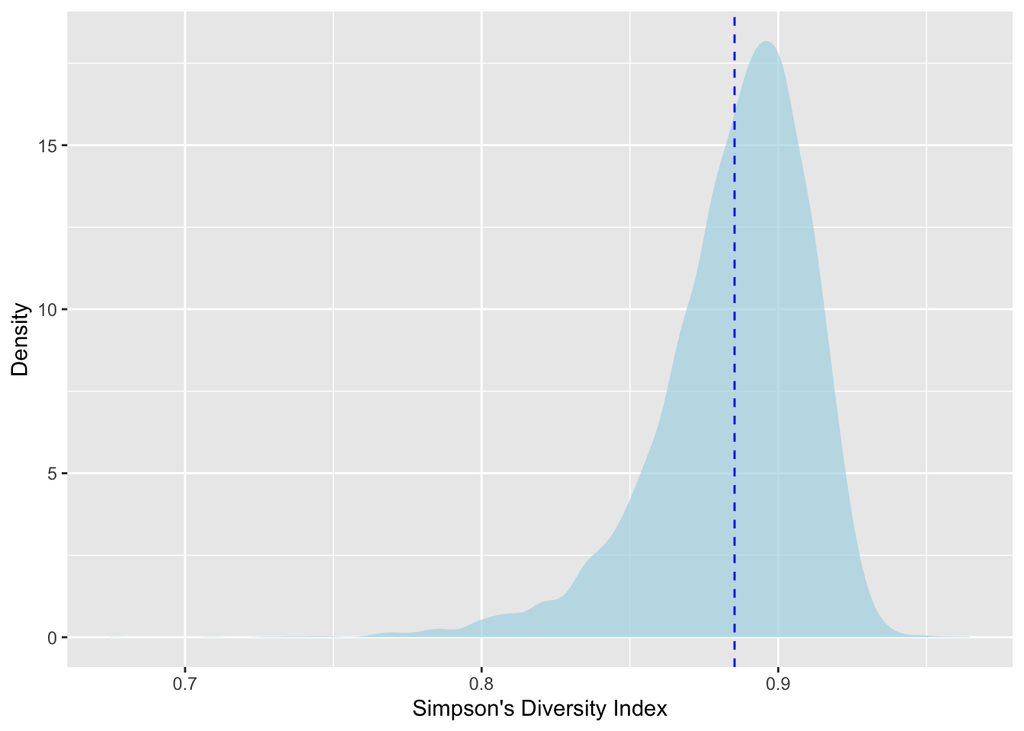

```r
ggplot() + geom_density(mapping=aes(x=sdiOakBoot$t),
                        fill="lightblue",color=NA,alpha=0.7) +
  geom_vline(xintercept = sdiOakBoot$t0,color="blue",linetype="dashed") +
  labs(x="Simpson's Diversity Index",y="Density")
```

Can use boot.ci function to calculate several different confidence intervals.

```r
boot.ci(sdiOakBoot)
```

```
## BOOTSTRAP CONFIDENCE INTERVAL CALCULATIONS
## Based on 10000 bootstrap replicates
##
## CALL :
## boot.ci(boot.out = sdiOakBoot)
##
## Intervals :
## Level      Normal              Basic
## 95%   ( 0.8342,  0.9365 )   ( 0.8475,  0.9502 )
##
## Level     Percentile            BCa
## 95%   ( 0.8204,  0.9231 )   ( 0.8071,  0.9199 )
## Calculations and Intervals on Original Scale
```

# My Work

I will attempt to use lapply() function to apply the boot function to each habitat

```r
# Here is my bootstrap function
sdiOakBoot<-function(x){
  boot(x, sdiBootFunc, R=1e4)
}

# Here I am applying it to all of the habitats
HabitatBoot<-lapply(birds[,-1], function(x) sdiOakBoot(x))
```

Now I will plot these as a ridgeline plot. First I need to make it into a data frame. This is definitely not the best way to do it but my lapply command produced lists within a list and I could not figure out how to work with that. I would love to learn more about how to better work with the bootstrap output because I found it extremely difficult and definitely used too much time and code to figure it out.

```r
# Turn bootstrap diversity values into data frames. I had to do this seperately for each habitat because they are all seperate lists
Oak1<-data.frame(HabitatBoot$Oak1$t)
Oak2<-data.frame(HabitatBoot$Oak2$t)
Oak3<-data.frame(HabitatBoot$Oak3$t)
Yew<-data.frame(HabitatBoot$Yew$t)
Sitka<-data.frame(HabitatBoot$Sitka$t)
Norway<-data.frame(HabitatBoot$Norway$t)
Mixed<-data.frame(HabitatBoot$Mixed$t)
Patchy<-data.frame(HabitatBoot$Patchy$t)
Swampy<-data.frame(HabitatBoot$Swampy$t)

# Make columns for diversity and habitat so R can match up the different data frames
Oak1$Habitat<-"Oak1"
names(Oak1)<-c("Diversity", "Habitat")
Oak2$Habitat<-"Oak2"
names(Oak2)<-c("Diversity", "Habitat")
Oak3$Habitat<-"Oak3"
names(Oak3)<-c("Diversity", "Habitat")
Yew$Habitat<-"Yew"
names(Yew)<-c("Diversity", "Habitat")
Sitka$Habitat<-"Sitka"
names(Sitka)<-c("Diversity", "Habitat")
Norway$Habitat<-"Norway"
names(Norway)<-c("Diversity", "Habitat")
Mixed$Habitat<-"Mixed"
names(Mixed)<-c("Diversity", "Habitat")
Patchy$Habitat<-"Patchy"
names(Patchy)<-c("Diversity", "Habitat")
Swampy$Habitat<-"Swampy"
names(Swampy)<-c("Diversity", "Habitat")

# bind them all together
a<-rbind(Oak1, Oak2)
a<-rbind(a, Oak3)
a<-rbind(a, Yew)
a<-rbind(a, Sitka)
a<-rbind(a, Norway)
a<-rbind(a, Mixed)
a<-rbind(a, Patchy)
a<-rbind(a, Swampy)
```

Now that I have a massive 90,000 line data frame of all the bootstrap outputs in all the habitats, I can plot it in a ridgeline plot.

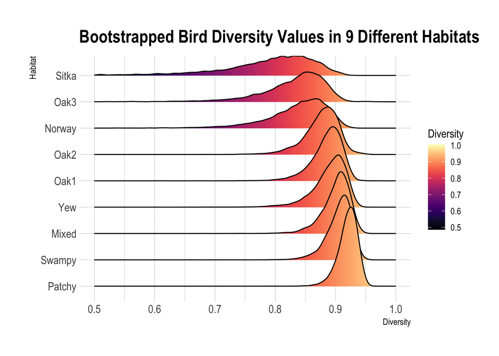

```r
ggplot(a, aes(x=Diversity, y=reorder(Habitat,-Diversity), fill=..x..))+
  geom_density_ridges_gradient(scale=3)+
  scale_fill_viridis(name="Diversity", option="A")+
  labs(title="Bootstrapped Bird Diversity Values in 9 Different Habitats")+
  theme_ipsum()+
  theme(panel.spacing=unit(0.1, "lines"),
        strip.text.x=element_text(size=8))+
  xlim(0.5, 1.00)+
  labs(y="Habitat")
```

It looks like these all have a fair bit of overlap and I don’t expect that any of these are significantly different. It is interesting how the spread of the values seems to decrease as the diversity increases.

Now I will plot the confidence intervals. Again this was a truly terrible and inefficient way to do this. The boot.ci output is strange to work with and I would love to learn how to do that better. I chose the percent method because it made the most sense to me. It would be interesting to compare the different methods.

```r
boot.ci(HabitatBoot$Oak1, type="perc")
CI1<-c("Oak1", 0.8246,  0.9223)
names(CI1)<-c("Habitat", "Lower", "Upper")

boot.ci(HabitatBoot$Oak2, type="perc")
CI2<-c("Oak2", 0.8055,  0.9210)
names(CI2)<-c("Habitat", "Lower", "Upper")

boot.ci(HabitatBoot$Oak3, type="perc")
CI3<-c("Oak3", 0.6935,  0.9029)
names(CI3)<-c("Habitat", "Lower", "Upper")

boot.ci(HabitatBoot$Yew, type="perc")
CI4<-c("Yew", 0.8179,  0.9294)
names(CI4)<-c("Habitat", "Lower", "Upper")

boot.ci(HabitatBoot$Sitka, type="perc")
CI5<-c("Sitka", 0.5384,  0.8924)
names(CI5)<-c("Habitat", "Lower", "Upper")

boot.ci(HabitatBoot$Norway, type="perc")
CI6<-c("Norway", 0.7010,  0.9069)
names(CI6)<-c("Habitat", "Lower", "Upper")

boot.ci(HabitatBoot$Mixed, type="perc")
CI7<-c("Mixed", 0.8447,  0.9337)
names(CI7)<-c("Habitat", "Lower", "Upper")

boot.ci(HabitatBoot$Patchy, type="perc")
CI8<-c("Patchy", 0.8829,  0.9446)
names(CI8)<-c("Habitat", "Lower", "Upper")

boot.ci(HabitatBoot$Swampy, type="perc")
CI9<-c("Swampy", 0.8544,  0.9379)
names(CI9)<-c("Habitat", "Lower", "Upper")

b<-rbind(CI1, CI2)
b<-rbind(b, CI3)
b<-rbind(b, CI4)
b<-rbind(b, CI5)
b<-rbind(b, CI6)
b<-rbind(b, CI7)
b<-rbind(b, CI8)
b<-rbind(b, CI9)
```

Now I will plot the averages of the bootstrapped diversity indexes and the bootstrapped confidence for each habitat.

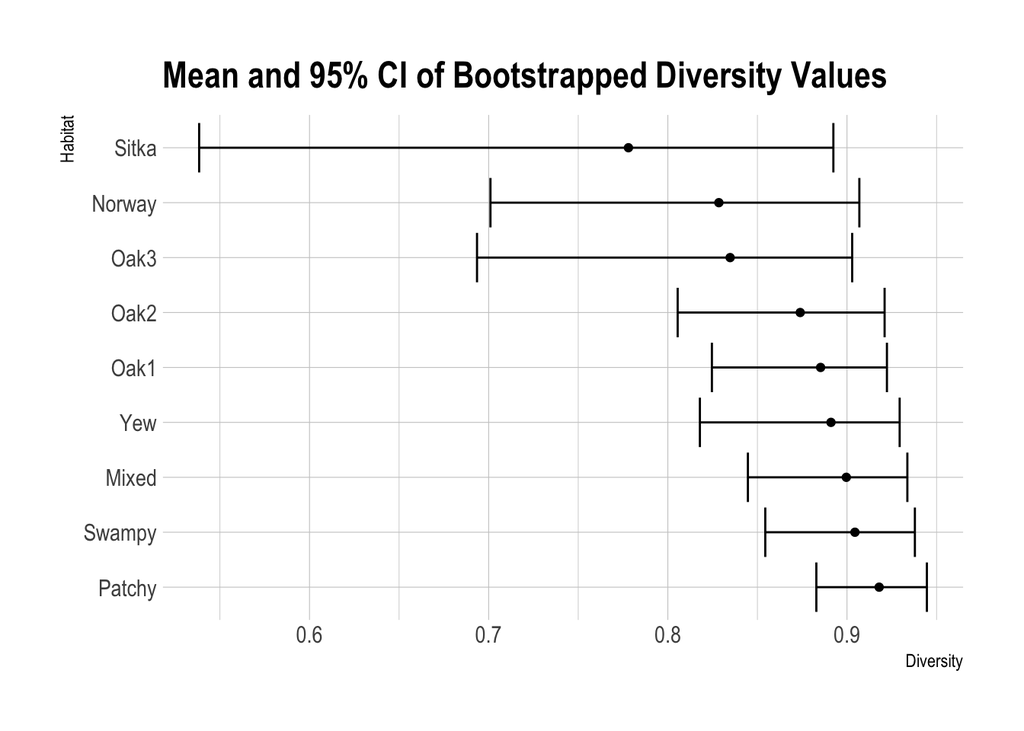

```r
avg<-data.frame(lapply(birds[,-1], sdiBootFunc))
avg<-pivot_longer(avg, 1:9)
names(avg)<-c("Habitat", "Diversity")
NewData<-merge(avg, b, by="Habitat")
NewData$Lower<-as.numeric(NewData$Lower)
NewData$Upper<-as.numeric(NewData$Upper)

ggplot(NewData, mapping=aes(x=Diversity, y=reorder(Habitat,-Diversity)))+
  geom_point()+
  geom_errorbar(mapping=aes(xmin=Lower, xmax=Upper))+
  theme_ipsum()+
  labs(y="Habitat", title="Mean and 95% CI of Bootstrapped Diversity Values")
```

It does not look like the diversity indexes are significantly different for any habitat. However, there are large differences in the spread which is very interesting and you wouldn’t be able to see with just the mean values.

Again, I would love some help on how to work with the bootstrap outputs better. Figuring out the initial code was pretty simple but trying to plot it was a whole other ball game.

Here is where I got my code for the ridgeline plot: https://www.r-graph-gallery.com/294-basic-ridgeline-plot.html